# PaperMicroUltimate

2024-10-04

In this section, we import and preprocess the key dataframes required for the analysis of the **vulvar microbiome**. The datasets include microbiome absolute abundances generated using Kraken, samples metadata, and gene expression counts, all of which are crucial for subsequent statistical and bioinformatic analysis.

- **Kraken Output**: The dataframe `kdata` represents the taxonomic abundances from the Kraken output. To eliminate potential human DNA contamination, reads associated with *Homo sapiens* have been filtered out.
- **Metadata**: The `meta` dataframe includes relevant clinical and experimental information about the cohort, containing details for each sample in the study, such as patient/control status.

```
##                             D_AM2 D_AM3   D_AM4 D_AM5 D_AM6   D_AM7  D_AM8
## Lactobacillus iners       1166586   871    1022    70   524 1036394 119660
## Lactobacillus crispatus    269605   794 1199405  1338 36969 1888495 202460
## Lactobacillus delbrueckii    2648   104    4078    89    63    9627   1189
## Lactobacillus acidophilus   19485     0   47289     0   636   51975   9760
## Lactobacillus jensenii        371   118  118435     8  1858  177278   7300
## Lactobacillus helveticus     6136    48   33223    16    79   45708    797
##                             D_AM9  D_AM10  D_AM11  D_AM12 D_AM13 D_AM14 D_AM15
## Lactobacillus iners       2216461 8978161     616     402 436497 954101    675
## Lactobacillus crispatus   1585844 1148160 1478040 3217188 296244  56914    507
## Lactobacillus delbrueckii    4449   19312    2451    4101    588    729   1862
## Lactobacillus acidophilus   43635  213636   58214  101147  18554  15062    122
## Lactobacillus jensenii     195743  100921  230102     538  30121  54018     18
## Lactobacillus helveticus    10053   25122    7821   19189   2764  13925     14
##                            D_AM16 D_AM17  D_AM18 D_AM19 D_AM20 D_AM21  D_AM22
## Lactobacillus iners       1875519 788813 1056704 503661   9470    855 7291334
## Lactobacillus crispatus    409137 668116  280710 762537   4849 406136   14040
## Lactobacillus delbrueckii    2092   1652    1846   1400     68    462    8023
## Lactobacillus acidophilus   35386  14821   17480  30950      0   4629  295432
## Lactobacillus jensenii      10110  42216     147 407292    946  65754     944
## Lactobacillus helveticus     5220   8870    4057   6011    229   1276    9945
##                           D_AM23
## Lactobacillus iners         1673
## Lactobacillus crispatus   234117
## Lactobacillus delbrueckii    366
## Lactobacillus acidophilus   5741
## Lactobacillus jensenii        29
## Lactobacillus helveticus    3439
```

### DECONTAMINATION (Decontam Package)

## **Filtering Dataframes Based on Read Counts**

In this step, we apply a filtering criteria to retain only the species with significant read counts in both control (H) and disease (D) groups. Specifically, we select species that have at least 100 reads in 50% or more of the samples within each condition. This filtering process ensures that the analysis focuses on the most abundant and relevant microorganisms across the dataset.

1. **Condition-Specific Filtering**: The columns in the `kdata` dataframe are relabeled based on the sample type (H or D), allowing easy identification of samples belonging to each condition. The dataframe is then split into two subsets: one for disease samples (`kdataD`) and one for healthy controls (`kdataH`).
2. **Selection Criteria**: Species that meet the threshold of 100 reads in at least half of the samples in either the disease or control group are retained. This ensures that only taxa with significant representation across the conditions are included in the analysis.
3. **Final Filtered Dataset**: The filtered dataframe `kdata_filt` contains the selected microorganisms, ordered by their total read counts across all samples, providing a curated list of species for downstream analysis.

This filtering step is essential for focusing the analysis on the most biologically relevant taxa and minimizing noise from low-abundance species.

##### Take the species with more than 100 reads in at least 50% of each condition (H/D)

## PCA on the TSS abundances

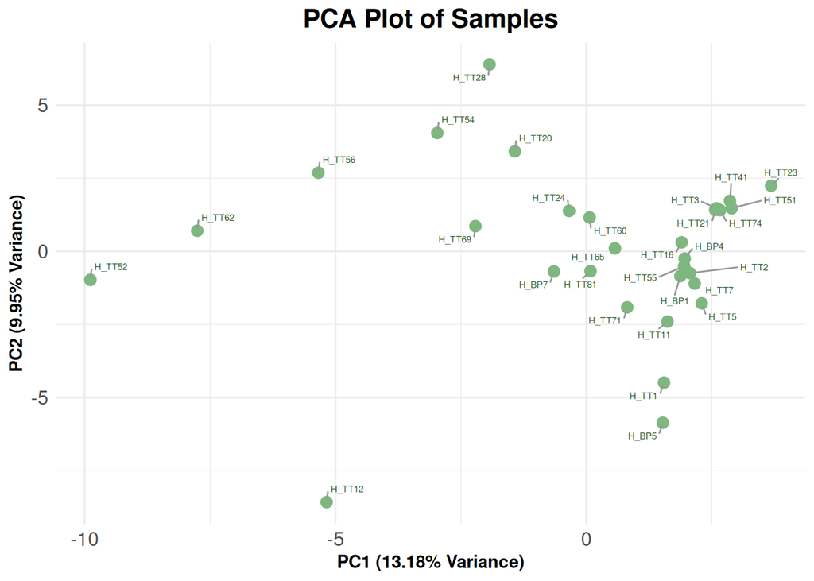

## NMDS on TSS data

```
## *** Best solution repeated 7 times
```

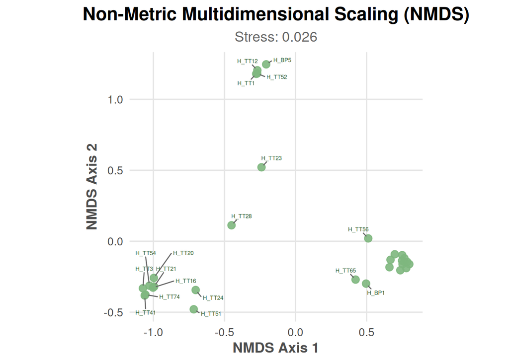

# Clustering

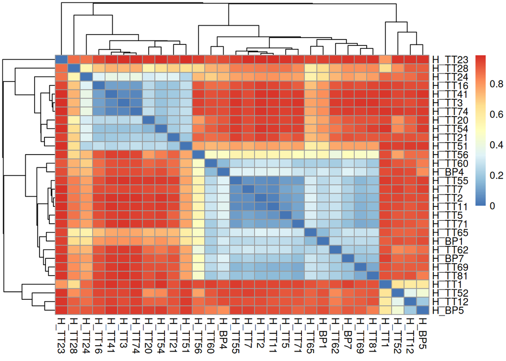

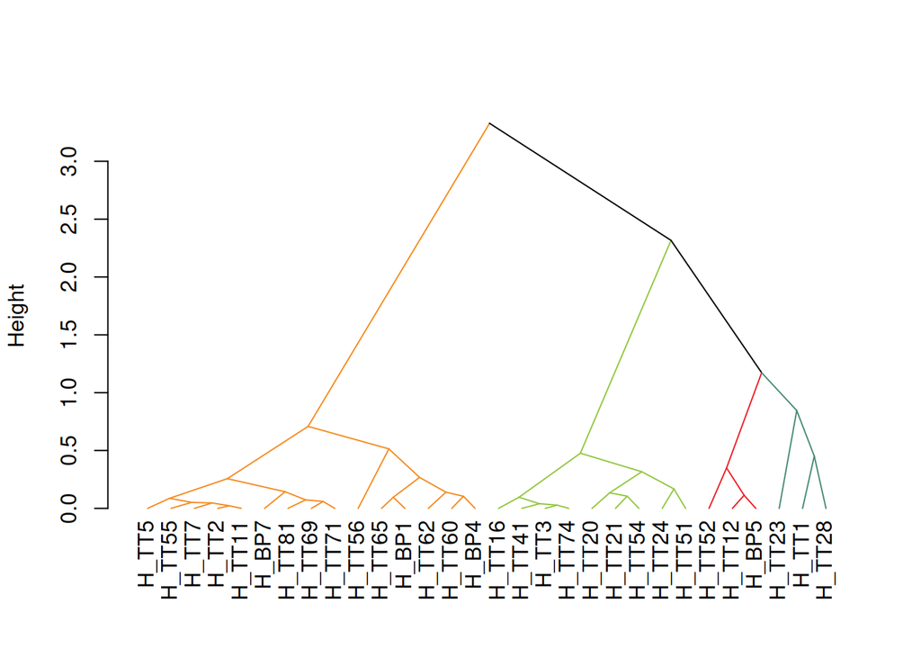

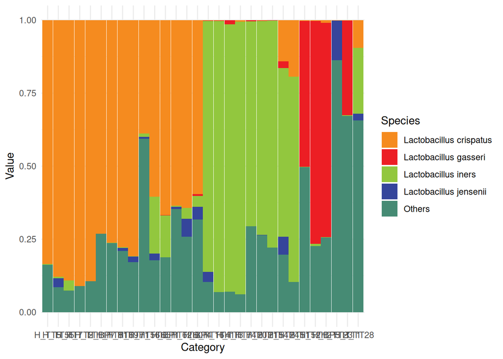

[figure not shown]

```r
mann_whitney <- function(taxa,group) {
  group1<-rownames(subset(cluster_col,Clusters==group))
  group2<-rownames(subset(cluster_col,Clusters!=group))
  test <- wilcox.test(taxa[group1], taxa[group2])
  median_change <- median(taxa[group1]) - median(taxa[group2])
  return(data.frame(pvalue=test$p.value,logMedianChange=median_change))
}

dgeobj <- DGEList(counts=kdata_filt)
dgeobj <- calcNormFactors(dgeobj,method="TMM")
counts_norm <- cpm(dgeobj, normalized.lib.sizes=TRUE, log=TRUE)


DGE<-lapply(unique(cluster_col$Clusters), function(cluster) {
           results<-apply(counts_norm, 1, function(taxa) mann_whitney(taxa,cluster))
           results<- do.call(rbind,results)
           results$padj<-p.adjust(results$pvalue, method = "BH")
           return(results)
             })
```

[output not shown]

[output cut: 345 more lines]

[output not shown]

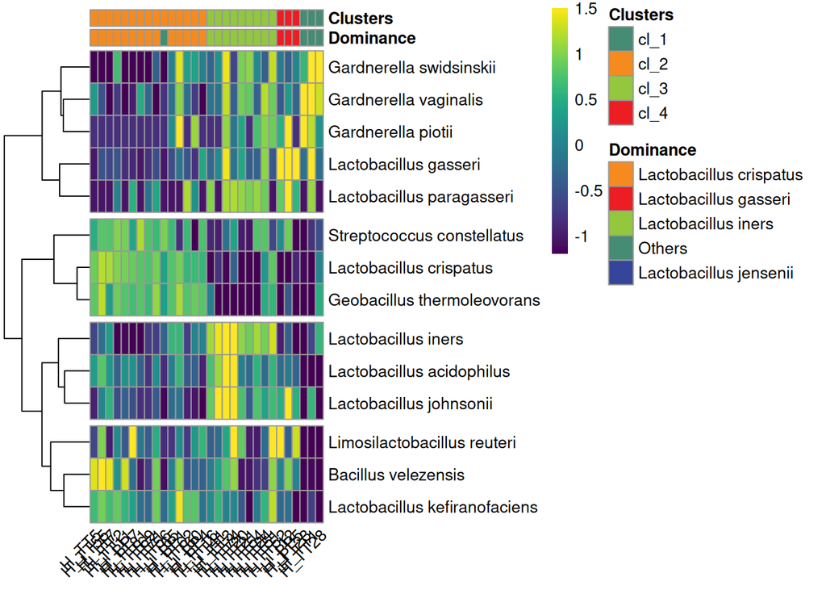

```r
names(DGE)=unique(cluster_col$Clusters)
DGE_filt<- lapply(DGE,function(x) rownames(subset(x,padj<=0.1 & abs(logMedianChange)>=0.5)))
DGE_filt_list <- unique(do.call(c,DGE_filt))

pheatmap(counts_norm[DGE_filt_list,match(ordered_samples,colnames(counts_norm))],
         cluster_rows = T,
         cluster_cols = F,
         annotation_colors  = cluster_colors,
         annotation_col = final_annotationcol,
         scale= "row",
         fontsize_row = 10,
         fontsize_col = 10,
         clustering_method = "ward.D2",
         # cutree_cols = 5,
         cutree_rows = 4,
         angle_col = 45,
         color = viridis(100),
         breaks= seq(-1.2,1.5,length.out=100)
)
```

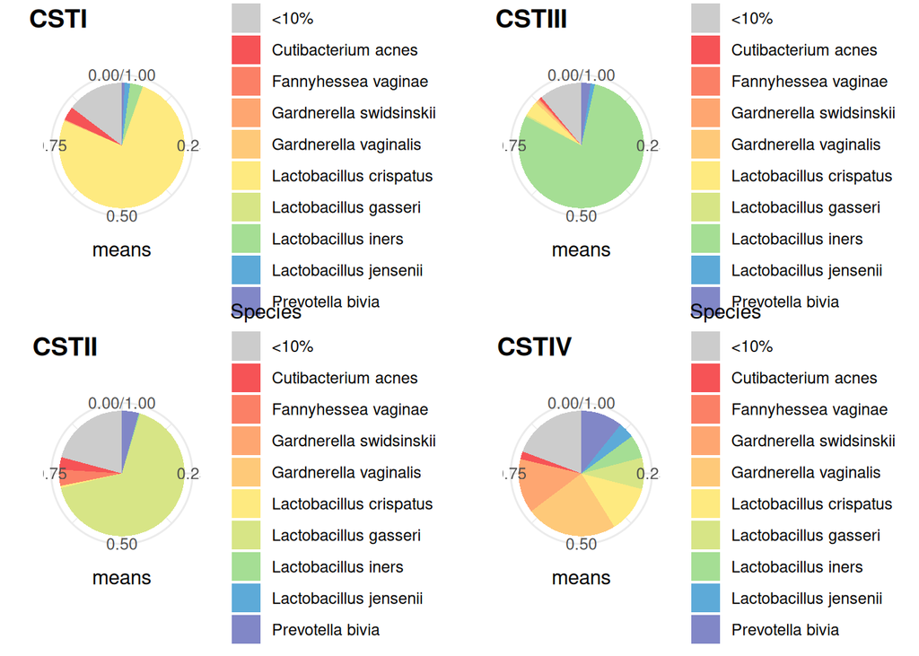

```r
bac2<-rowSums(apply(kdata_frac,2,FUN = function(x) x>=0.1))>=1
genus_frac_filt2<-kdata_frac[bac2,]
genus_frac_filt2["<10%",]<-1-colSums(genus_frac_filt2)
mypalette=c("grey80","#f65356","#fb8066","#fea671","#fec979","#feea80","#d7e586","#a5de94","#5daad8","#8187c7","#c56bba")

inerssamples<-rownames(annotationcol)[which(annotationcol$Dominance == "Lactobacillus iners")]
inersfrac<-genus_frac_filt2[,match(inerssamples,colnames(genus_frac_filt2))]
inersfrac$means<-rowMeans(inersfrac)
crispatussamples<-rownames(annotationcol)[which(annotationcol$Dominance == "Lactobacillus crispatus")]
crispatusfrac<-genus_frac_filt2[,match(crispatussamples,colnames(genus_frac_filt2))]
crispatusfrac$means<-rowMeans(crispatusfrac)
gasserisamples<-rownames(annotationcol)[which(annotationcol$Dominance == "Lactobacillus gasseri")]
gasserifrac<-genus_frac_filt2[,match(gasserisamples,colnames(genus_frac_filt2))]
gasserifrac$means<-rowMeans(gasserifrac)
otherssamples<-rownames(annotationcol)[which(annotationcol$Dominance == "Others")]
othersfrac<-genus_frac_filt2[,match(otherssamples,colnames(genus_frac_filt2))]
othersfrac$means<-rowMeans(othersfrac)

inplot<-ggplot(data=inersfrac,aes(x="",y=means,fill = rownames(inersfrac)))+
  geom_bar(stat="identity",width = 1)+
  scale_fill_manual(values = mypalette)+
  coord_polar("y",start=0)+
  xlab(label = "")+
  labs(fill="Species")+
  theme_minimal()

crisplot<-ggplot(data=crispatusfrac,aes(x="",y=means,fill = rownames(crispatusfrac)))+
  geom_bar(stat="identity",width = 1)+
  scale_fill_manual(values = mypalette)+
  coord_polar("y",start=0)+
    xlab(label = "")+
    labs(fill="Species")+
  theme_minimal()

gassplot<-ggplot(data=gasserifrac,aes(x="",y=means,fill = rownames(gasserifrac)))+
  geom_bar(stat="identity",width = 1)+
  scale_fill_manual(values = mypalette)+
  coord_polar("y",start=0)+
    labs(fill="Species")+
    xlab(label = "")+
  theme_minimal()


othersplot<-ggplot(data=othersfrac,aes(x="",y=means,fill = rownames(inersfrac)))+
  geom_bar(stat="identity",width = 1)+
  scale_fill_manual(values = mypalette)+
  coord_polar("y",start=0)+
    labs(fill="Species")+
    xlab(label = "")+
  theme_minimal()

ggarrange(crisplot,inplot, gassplot, othersplot,
                    labels = c("CSTI", "CSTIII", "CSTII","CSTIV"),
                    ncol = 2, nrow = 2)
```

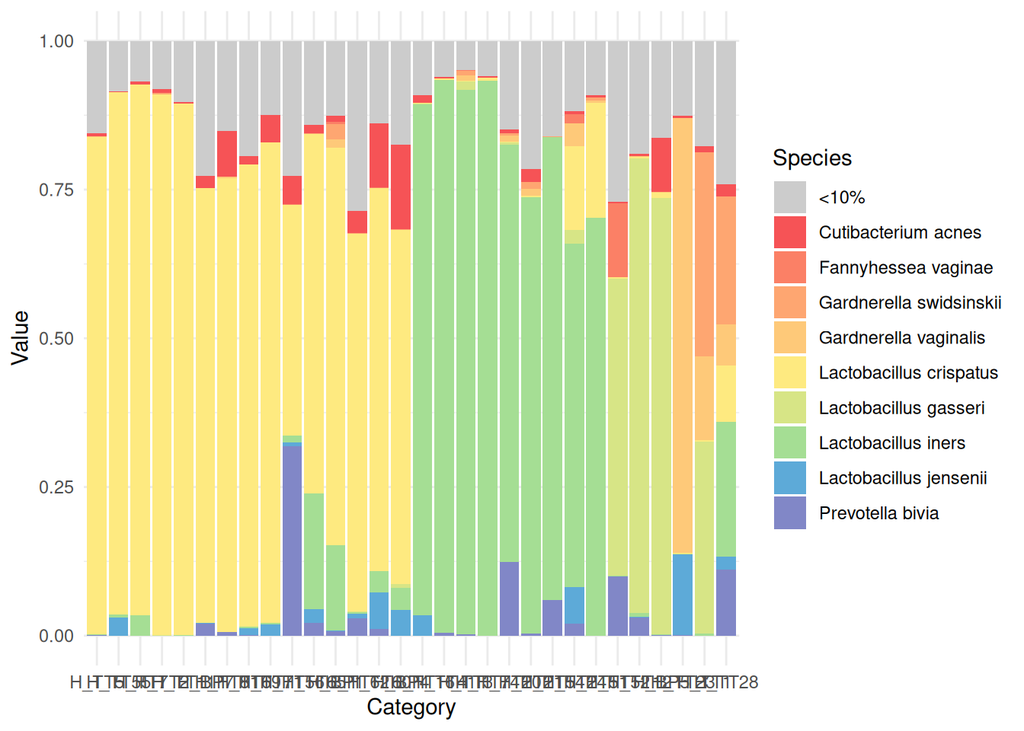

```r
genus_frac_filt2$Species <- rownames(genus_frac_filt2)

#### Plot Abbondanze ####
data_long_10prc <- genus_frac_filt2 %>%
  pivot_longer(
    cols = starts_with("H_"),   # Specify the columns to pivot
    names_to = "Category",       # Name of the new column for the original column names
    values_to = "Value"          # Name of the new column for the values
  )

library(forcats)

# # Assicurati che "Others" sia l'ultimo livello del fattore Species
#     data_long_10prc$Species <- fct_relevel(data_long_10prc$Species, c("Others"), after = 0)
#     data_long_10prc$Species <- fct_relevel(data_long_10prc$Species, c("Lactobacillus crispatus"), after = 1)
#     data_long_10prc$Species <- fct_relevel(data_long_10prc$Species, c("Lactobacillus iners"), after = 2)
#     data_long_10prc$Species <- fct_relevel(data_long_10prc$Species, c("Lactobacillus jensenii"), after = 3)
#
data_long_10prc$Category<-factor(data_long_10prc$Category,levels = ordered_samples)
ggplot(data_long_10prc[,], aes(y = Value, x = Category, fill = Species)) +
  geom_col() +
  scale_fill_manual(values = mypalette)+
  theme_minimal()  # Usa un tema semplice
```

```r
data_PCA = prcomp(t(kdata_frac), scale = T)
scores = data.frame(sample = rownames(data_PCA$x), PC1 = data_PCA$x[,1], PC2 = data_PCA$x[,2], PC3 = data_PCA$x[,3])
scores$sample = rownames(scores)
scores$status = sapply(strsplit(scores$sample,"_"),"[", 1)
scores$PatientID = sapply(strsplit(scores$sample,"_"),"[", 2)
scores = merge(scores,final_annotationcol,by = 0)
```

### **PCA Plot on PC1 vs PC2**

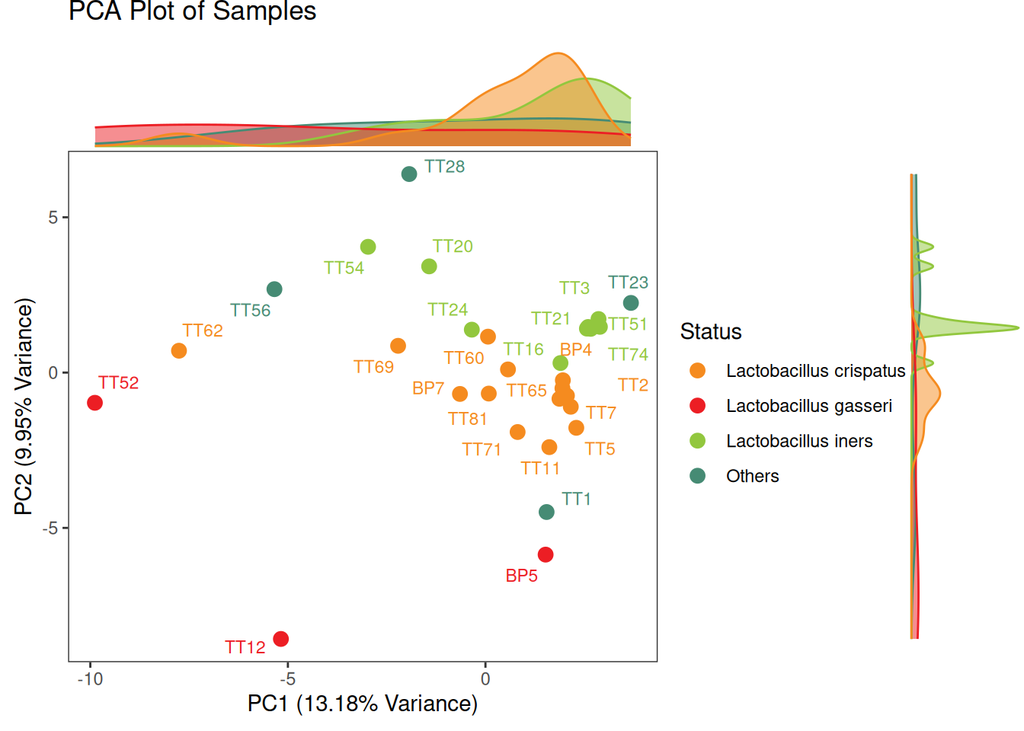

```r
nreads_min<-min(colSums(kdata_filt))
nreads_max<-max(colSums(kdata_filt))
fold<-round(nreads_max/nreads_min,0)

kdata_subs<-rrarefy(t(kdata_filt),nreads_min)
```

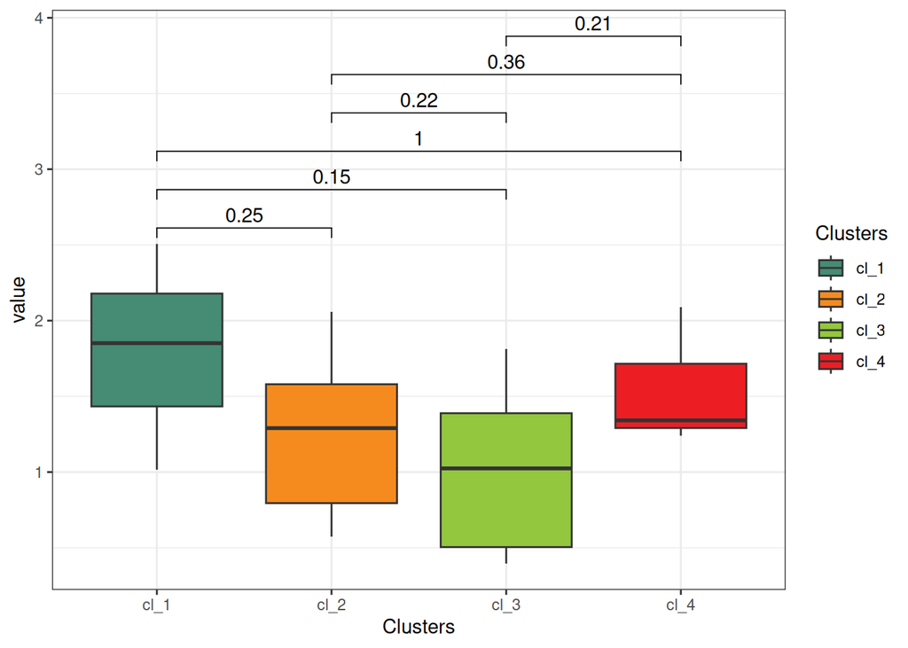

```r
alpha_subs<-diversity(kdata_subs)#t(kdata[,match(ordered_samples,colnames(kdata))])
alphasubs=data.frame(samples=names(alpha_subs),value=alpha_subs)
alphasubs$samples<-factor(alphasubs$samples,ordered_samples)
alphasubs<-merge(alphasubs,final_annotationcol,by=0) %>% tibble::column_to_rownames("Row.names")

my_comparisons <- list( c("cl_1","cl_2"),c("cl_1","cl_3"),c("cl_1","cl_4"),c("cl_3","cl_2"),c("cl_4","cl_2"),c("cl_3","cl_4"))

ggplot(alphasubs,aes(x=Clusters,y=value,fill = Clusters))+
  geom_boxplot()+
  scale_fill_manual(values = c("cl_1" = "#468B74" , "cl_2" ="#F58B1F", "cl_3" = "#92C73E","cl_4" =  "#EC1E24"))+
  stat_compare_means(comparisons=my_comparisons)+
  theme_bw()
```

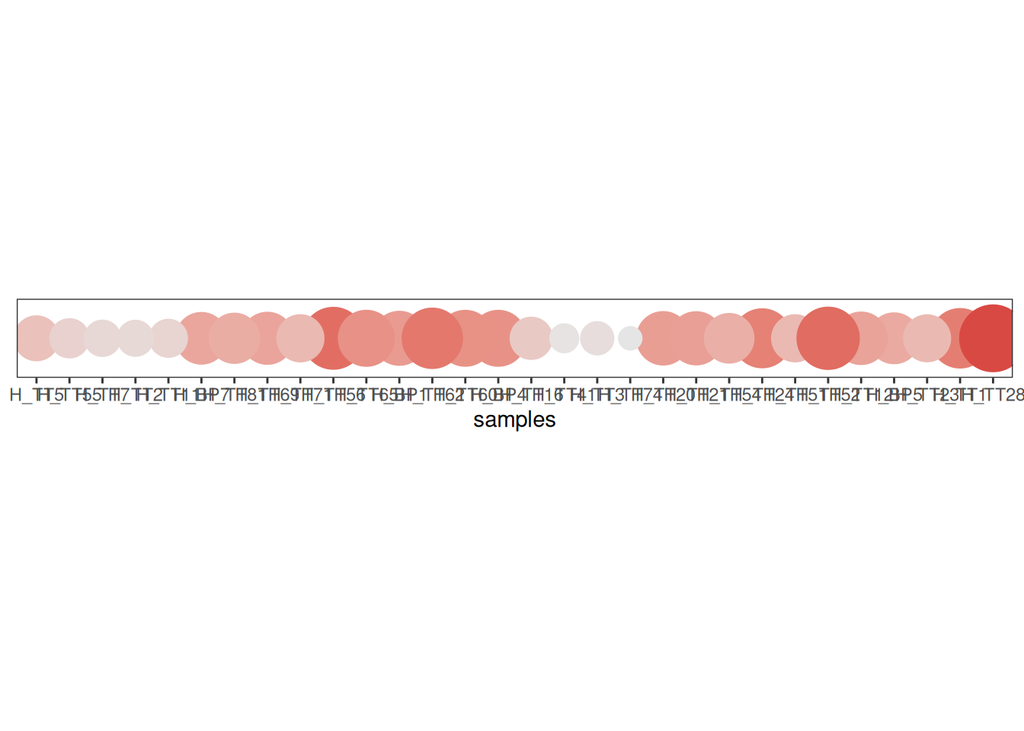

```r
ggplot(alphasubs, aes(x = samples, y = factor(1), size = value, colour = value)) +
  geom_point() +
  scale_size_continuous(range = c(5, 15)) +
  scale_color_gradient(low = "grey90", high = "#D94943") +  # Intensity of color
  theme_bw() +
  theme(
    axis.title.y = element_blank(),
    axis.text.y = element_blank(),
    axis.ticks.y = element_blank(),
    panel.grid = element_blank(),
    legend.position = "none"  # Hide the legend
  )+
  coord_fixed(ratio = 2)
```

```r
genus_frac<-kdata_frac
genus_frac$genus<-sapply(strsplit(rownames(genus_frac)," "),"[",1)
genus_frac<-genus_frac %>%
  group_by(genus) %>%
  summarise(across(everything(), sum, na.rm = TRUE)
  )%>% tibble::column_to_rownames("genus")
```

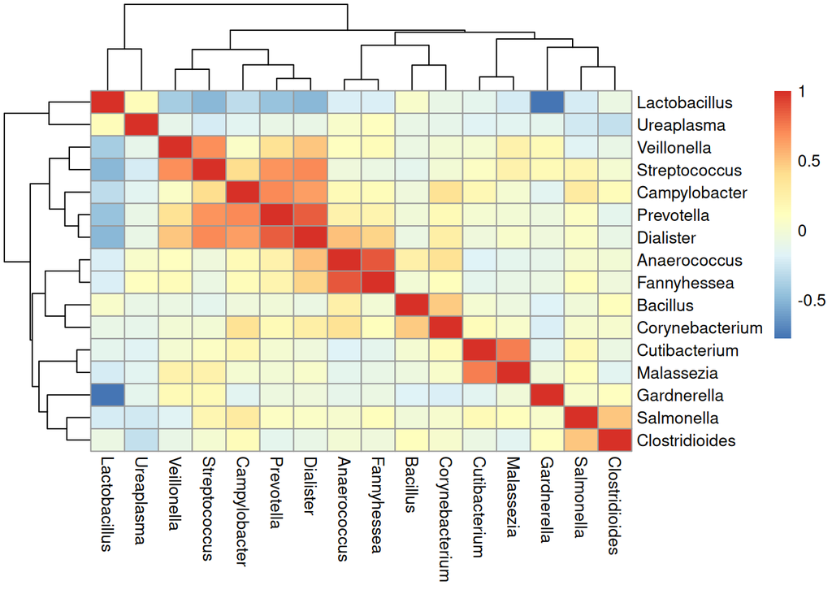

```r
genus_frac$sum <- rowSums(genus_frac)

genus_frac<-arrange(genus_frac,desc(sum))
genus_frac$sum<-NULL

prc=0.03
#--- Show only the ones over 20%
bac<-rowSums(apply(genus_frac,2,FUN = function(x) x>= prc))>=1
genus_frac_filt<-genus_frac[bac,]


correlation<-cor(t(genus_frac_filt))
pheatmap(correlation)
```

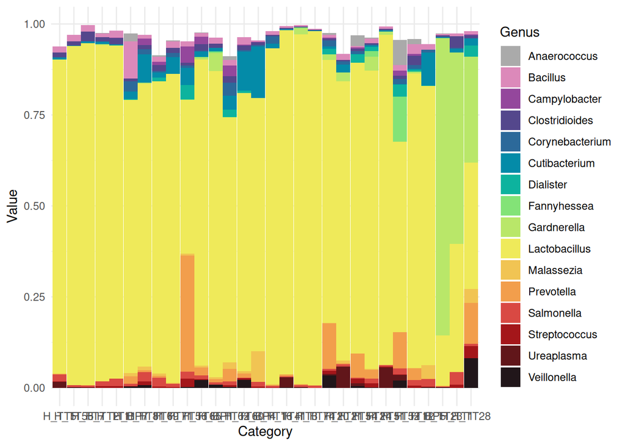

```r
mypalette<-c("#aaa","#dc89ba","#94479c","#54478c" ,"#2c699a", "#048ba8", "#0db39e", "#83e377", "#b9e769", "#efea5a", "#f1c453", "#f29e4c","#D94943","#a4161a","#61161a","#21161a")
genus_frac_filt$Genus <- rownames(genus_frac_filt)

#### Plot Abbondanze ####
data_long_gen <- genus_frac_filt %>%
  pivot_longer(
    cols = starts_with("H_"),   # Specify the columns to pivot
    names_to = "Category",       # Name of the new column for the original column names
    values_to = "Value"          # Name of the new column for the values
  )


data_long_gen<-merge(data_long_gen,final_annotationcol,by.x="Category",by.y=0)
data_long_gen$Category<-factor(data_long_gen$Category,levels = ordered_samples)

###ORDINA PER CLUSTER
ggplot(data_long_gen, aes(y = Value, x = Category, fill = Genus)) +
  geom_col(width = 0.98) +
  scale_fill_manual(values = mypalette)+
  theme_minimal()  # Usa un tema semplice
```

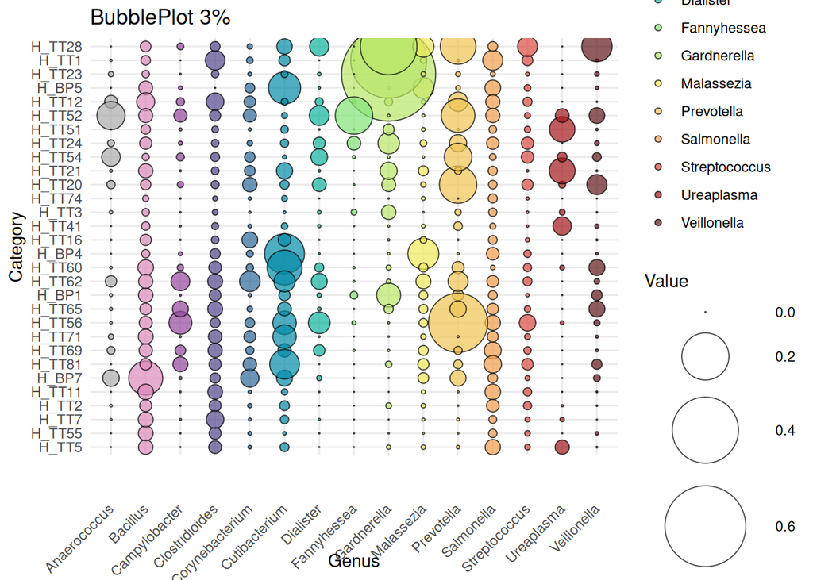

```r
data_long_gen<-subset(data_long_gen,Genus!="Lactobacillus")

ggplot(data_long_gen, aes(x = Genus, y = Category, size = Value, fill = Genus)) +
  geom_point(alpha = 0.7, shape = 21) +
  ggtitle(label=paste0("BubblePlot ",prc*100,"%"))+
  scale_fill_manual(values = mypalette)+
  scale_size_continuous(range = c(0, 27)) +  # Adjust the range for bubble sizes
  theme_minimal()+
  theme(legend.position = "right",axis.text.x = element_text(angle = 45, vjust = 0.5, hjust=1))  # Position the legend as needed
```

```r
colSums(genus_frac_filt[,-ncol(genus_frac_filt)])
```

```
##     H_TT5    H_TT55     H_TT7     H_TT2    H_TT11     H_BP7    H_TT81    H_TT69
## 0.9382584 0.9699062 0.9969243 0.9746035 0.9813947 0.9744055 0.9703697 0.9143147
##    H_TT71    H_TT56    H_TT65     H_BP1    H_TT62    H_TT60     H_BP4    H_TT16
## 0.9542080 0.9520431 0.9760850 0.9628648 0.9112307 0.9635079 0.9552955 0.9801998
##    H_TT41     H_TT3    H_TT74    H_TT20    H_TT21    H_TT54    H_TT24    H_TT51
## 0.9943845 0.9973526 0.9863798 0.9751447 0.9178429 0.9684843 0.9624876 0.9934567
##    H_TT52    H_TT12     H_BP5    H_TT23     H_TT1    H_TT28
## 0.9558731 0.9581740 0.9447955 0.9742749 0.9734799 0.9806933
```

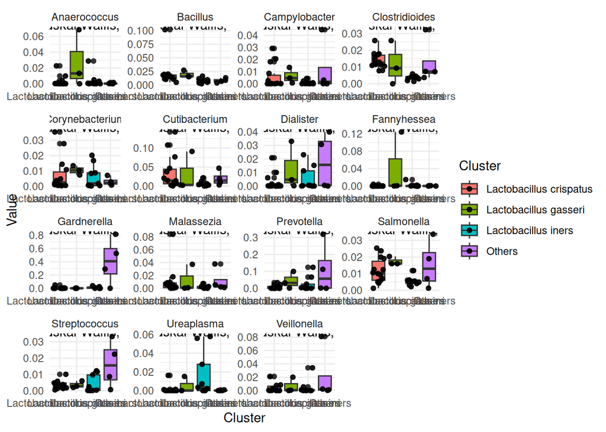

```r
# Pairwise comparisons: Specify the comparisons you want
my_comparisons <- list( c("Lactobacillus crispatus", "Lactobacillus iners"), c("Lactobacillus iners", "Lactobacillus gasseri"), c("Lactobacillus crispatus", "Others"),c("Lactobacillus gasseri", "Others"),c("Lactobacillus iners", "Others"),c("Lactobacillus crispatus", "Lactobacillus gasseri"))


data_long_gen$Cluster<-final_annotationcol[match(data_long_gen$Category,rownames(final_annotationcol)),]$Dominance

ggplot(data_long_gen,aes(x = Cluster,y=Value,fill = Cluster))+
  geom_boxplot()+
  geom_jitter(alpha=0.9)+
  facet_wrap(~Genus,scales="free")+
  stat_compare_means()+
  theme_minimal()
```

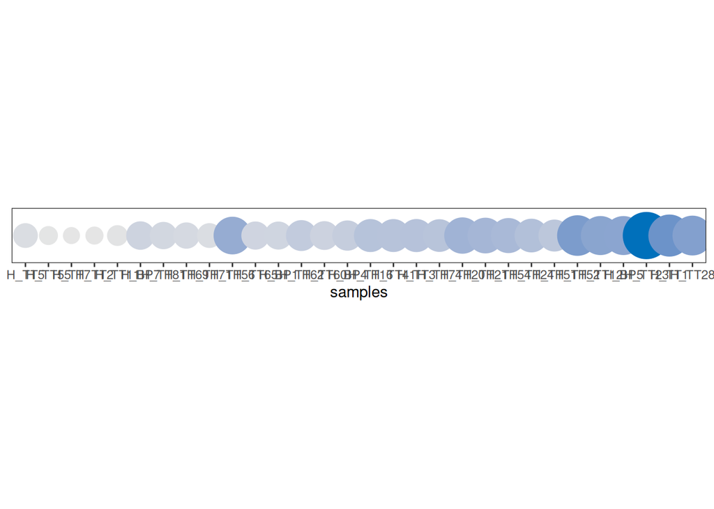

```r
association <- read.csv("MicroPhenoDBAssociationScores.csv") %>% select(-Pmid, -Association_ID)
key_cols <- setdiff(names(association), "Score")


merged_dupl <- merge(kdata_frac, association, by.x = 0, by.y = "Microbe")

# Compute the mean of 'Score' while grouping by 'Row.names'
Scores <- merged_dupl %>%
    group_by(Row.names) %>%
    summarise(Score = mean(Score, na.rm = TRUE), .groups = "drop") %>%
    tibble::column_to_rownames("Row.names")

merged <- merge(kdata_frac,Scores,by=0)%>%tibble::column_to_rownames("Row.names")


diseasescore<-list()
for (names in setdiff(colnames(merged), c("Score","Genus"))) {

diseasescore[names]<-sum(merged[,names]*merged[,"Score"])

}

disbiodb=data.frame(samples=names(unlist(diseasescore)),dysbio=unlist(diseasescore))
disbiodb$samples=factor(disbiodb$samples,ordered_samples)
disbiodb$dysbio<-disbiodb$dysbio

ggplot(disbiodb, aes(x = samples, y = factor(1), size = dysbio, colour = dysbio)) +
  geom_point() +
  scale_size_continuous(range = c(5, 15)) +
  scale_color_gradient(low = "grey90", high = "#0070BB") +  # Intensity of color
  theme_bw() +
  theme(
    axis.title.y = element_blank(),
    axis.text.y = element_blank(),
    axis.ticks.y = element_blank(),
    panel.grid = element_blank(),
    legend.position = "none"  # Hide the legend
  )+
  coord_fixed(ratio = 2)
```